# HSC Survey Results

# Scots Bay Survey # 8 Results from 27/08/2023

## Survey Details

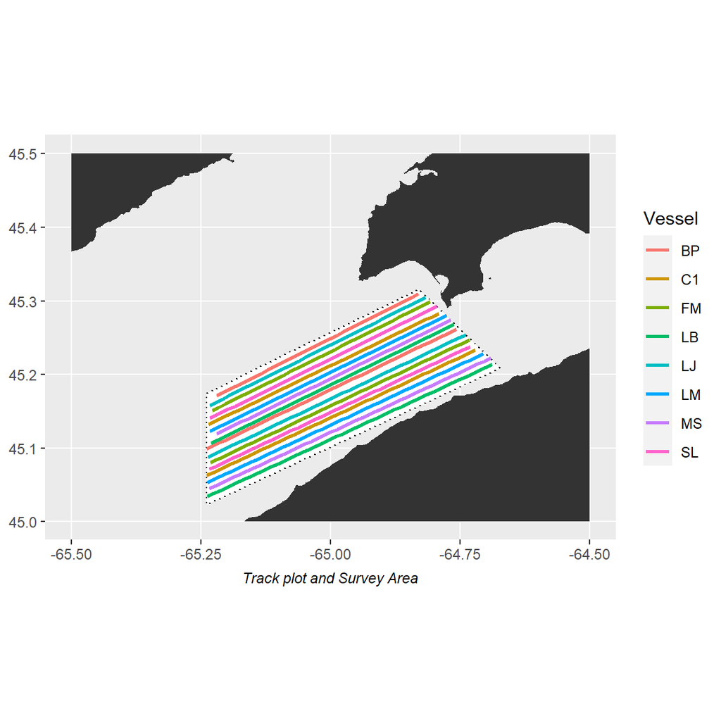

8 commercial purse seiners conducted this fishing survey on 27/08/2023 starting at 20:00:00, which was 0.8 hours before hide tide.

All vessels ran two transects each in the Main Survey Box.

There was a plankton tow and replicate conducted and CTD cast by Lady Melissa.

A total of 2,476 tags were applied during the survey over 10 event(s) from 2023-08-27 to 2023-08-29 from 4 vessel(s).

Samples were obtained for target strength estimation.

### Tides Tables

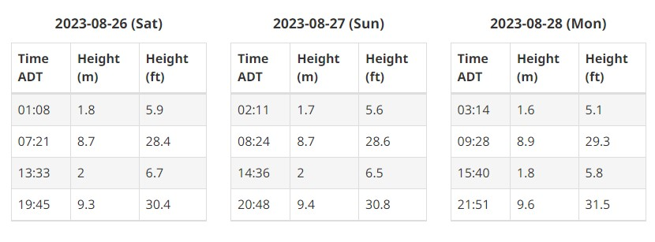

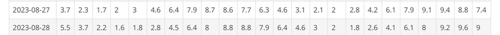

Tide Schedule for Margaretsville NS, Station #315m Source: www.waterlevels.gc.ca

### Acoustic Equipment

Each vessel was equipped with a Simrad ES38-18/200-18C combi (2-in-1) transducer prior to the survey that contains a 38kHz split beam and 200 kHz single beam transducer. Data was logged to the computer hard-drive for post-processing. All participating boats were calibrated on 38kHz before the survey.

## Survey Results

### Main Results

The results are subject to change as DFO will re-evaluate data editing, area estimation and apply a target strength.

**Preliminary biomass prediction for Scots Bay using standardized parallel transects is 2,897mt, and with turnover applied 2,300mt.**

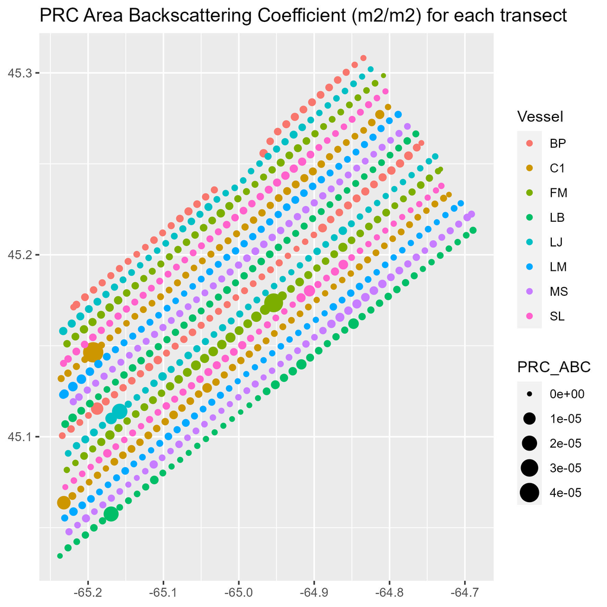

### Transect Details

Table 1: Transect Details

| Vessel | Transect # | Date/Time Start | Date/Time End | Start Lon | Start Lat | End Lon | End Lat | Location | Distance (km) | Speed |
| --- | --- | --- | --- | --- | --- | --- | --- | --- | --- | --- |
| BP | T01 | 2023-08-28 00:49:31 | 2023-08-28 03:25:48 | -65.239 | 45.099 | -64.758 | 45.261 | SB | 41.99 | 8.71 |
| BP | T02 | 2023-08-28 03:49:16 | 2023-08-28 05:46:20 | -64.831 | 45.309 | -65.219 | 45.171 | SB | 34.70 | 9.60 |
| C1 | T01 | 2023-08-27 23:54:11 | 2023-08-28 02:42:33 | -65.239 | 45.063 | -64.721 | 45.233 | SB | 46.17 | 8.88 |
| C1 | T02 | 2023-08-28 03:06:09 | 2023-08-28 05:24:15 | -64.791 | 45.283 | -65.236 | 45.132 | SB | 39.68 | 9.31 |
| FM | T01 | 2023-08-29 00:49:18 | 2023-08-29 03:36:51 | -65.232 | 45.080 | -64.732 | 45.247 | SB | 43.66 | 8.44 |
| FM | T02 | 2023-08-29 04:02:13 | 2023-08-29 06:14:38 | -64.808 | 45.299 | -65.228 | 45.151 | SB | 37.04 | 9.06 |
| LB | T01 | 2023-08-27 23:36:57 | 2023-08-28 02:36:07 | -65.238 | 45.034 | -64.689 | 45.213 | SB | 47.87 | 8.66 |
| LB | T02 | 2023-08-28 03:06:07 | 2023-08-28 05:29:29 | -64.762 | 45.268 | -65.230 | 45.107 | SB | 41.16 | 9.30 |
| LJ | T01 | 2023-08-27 23:50:43 | 2023-08-28 02:36:34 | -65.236 | 45.088 | -64.739 | 45.254 | SB | 43.58 | 8.51 |
| LJ | T02 | 2023-08-28 03:01:38 | 2023-08-28 05:14:57 | -64.817 | 45.305 | -65.233 | 45.158 | SB | 36.77 | 8.94 |
| LM | T01 | 2023-08-27 23:38:50 | 2023-08-28 02:35:52 | -65.238 | 45.053 | -64.706 | 45.228 | SB | 46.37 | 8.49 |
| LM | T02 | 2023-08-28 02:59:52 | 2023-08-28 05:18:02 | -64.777 | 45.280 | -65.233 | 45.123 | SB | 40.12 | 9.41 |
| MS | T01 | 2023-08-27 23:50:42 | 2023-08-28 02:46:42 | -65.234 | 45.045 | -64.691 | 45.222 | SB | 48.29 | 8.89 |
| MS | T02 | 2023-08-28 03:15:20 | 2023-08-28 05:42:36 | -64.768 | 45.274 | -65.220 | 45.119 | SB | 40.41 | 8.89 |
| SL | T01 | 2023-08-28 00:47:07 | 2023-08-28 03:37:55 | -65.234 | 45.071 | -64.731 | 45.238 | SB | 44.95 | 8.53 |
| SL | T02 | 2023-08-28 04:02:14 | 2023-08-28 06:30:36 | -64.795 | 45.292 | -65.233 | 45.140 | SB | 39.47 | 8.62 |

### Survey Summary

Table 2: Acoustic Survey Results

| Vessel | Transect No. | Target Strength (db/kg) | Mean Sa (/m2) | Biomass Density (kg/m2) |
| --- | --- | --- | --- | --- |
| FM | T01 | -35.5 | -55.527 | 0.010 |
| C1 | T02 | -35.5 | -57.040 | 0.007 |
| LB | T01 | -35.5 | -58.539 | 0.005 |
| LJ | T01 | -35.5 | -58.563 | 0.005 |
| BP | T01 | -35.5 | -58.646 | 0.005 |
| FM | T02 | -35.5 | -59.368 | 0.004 |
| LM | T02 | -35.5 | -59.439 | 0.004 |
| C1 | T01 | -35.5 | -59.485 | 0.004 |
| BP | T02 | -35.5 | -59.685 | 0.004 |
| SL | T01 | -35.5 | -59.870 | 0.004 |
| MS | T01 | -35.5 | -60.064 | 0.003 |
| SL | T02 | -35.5 | -60.127 | 0.003 |
| LB | T02 | -35.5 | -60.183 | 0.003 |
| MS | T02 | -35.5 | -60.737 | 0.003 |
| LJ | T02 | -35.5 | -60.851 | 0.003 |
| LM | T01 | -35.5 | -61.799 | 0.002 |

Note:  
Transects are listed from greatest to least backscatter.

Table 3: Survey Summary Table

| Layer | Target Strength | Area (km2) | Mean Sa | Density (kg/m2) | Biomass (tons) | Percent Area | Percent Biomass | Standard Error (tons) | Standard Error (%) |
| --- | --- | --- | --- | --- | --- | --- | --- | --- | --- |
| Main Box | -35.5 | 661 | -59.083 | 0.0044 | 2,896.659 | 77.5 | NA | 303.87 | 10.49 |
| Northern Box | NA | 77 | NA | NA | NA | 9.0 | NA | NA | NA |
| Eastern Box | NA | 115 | NA | NA | NA | 13.5 | NA | NA | NA |

### Greatest Biomass Densities

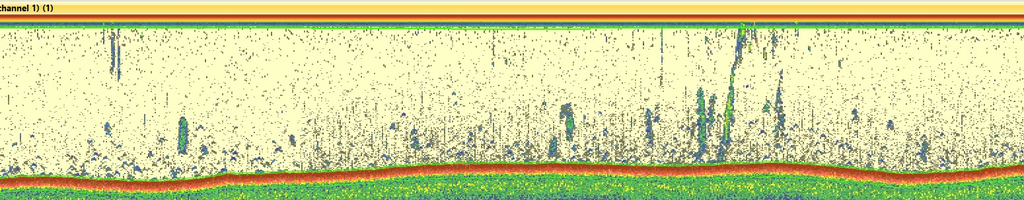

A snip from the transect with the greatest biomass density (kg/m2)

The single point with the largest biomass density (kg/m2) was recorded by **C1**, at the following location:

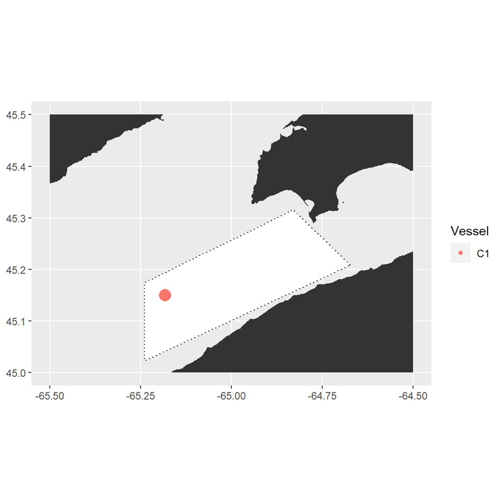

The transect with the greatest average biomass density (kg/m2) was recorded by **FM**, at the following location:

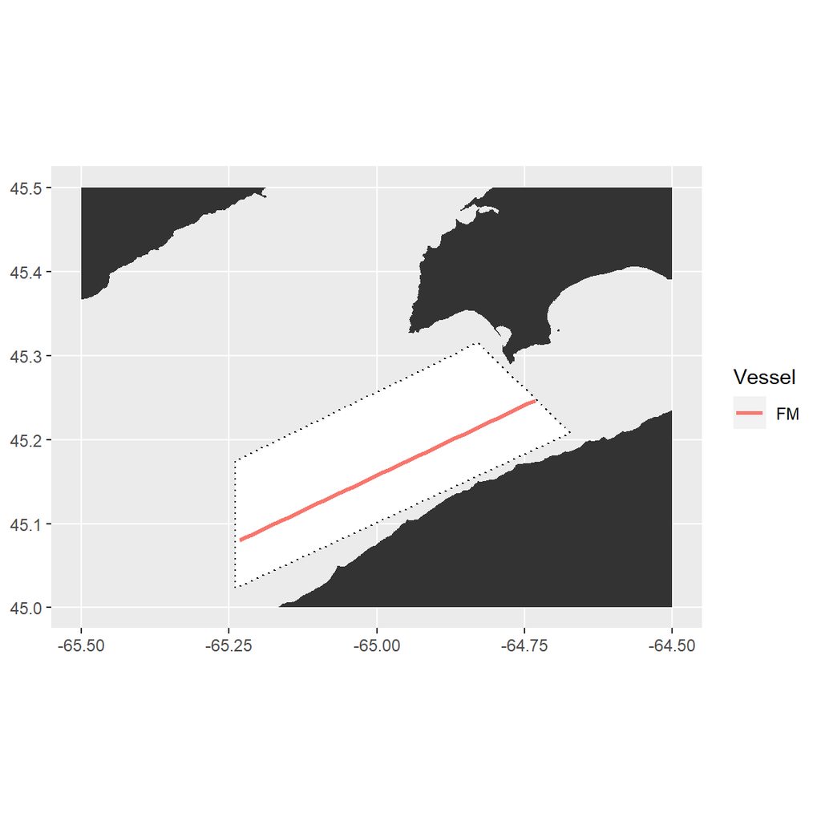

### Annual Summaries

Table 4: Annual Comparison Table

| Ground | Survey Number | Current Year Survey Date | Current Year HSC Estimate | Current Year HSC Turnover Adjusted | Previous Year Survey Date | Previous Year HSC Estimate | Previous Year HSC Turnover Adjusted | Previous Year DFO Estimate | Previous Year DFO Turnover Adjusted |
| --- | --- | --- | --- | --- | --- | --- | --- | --- | --- |
| Scots Bay | 1 | 2023-05-22 | 40,856.000 | 40,856 | 2022-05-29 | 92,542 | 92,542 | 99,092 | 99,092 |
| Scots Bay | 2 | 2023-06-06 | 113,767.329 | 108,783 | 2022-06-12 | 93,163 | 80,663 | 113,792 | 100,407 |
| Scots Bay | 3 | 2023-06-18 | 34,279.387 | 15,158 | 2022-06-26 | 30,535 | 17,624 | 29,429 | 13,709 |
| Scots Bay | 4 | 2023-07-02 | 11,744.776 | 5,113 | 2022-07-10 | 9,886 | 5,432 | 7,892 | 3,515 |
| Scots Bay | 5 | 2023-07-16 | 19,282.634 | 17,575 | 2022-07-26 | 11,954 | 10,869 | 11,402 | 10,536 |
| Scots Bay | 6 | 2023-07-30 | 4,549.933 | 1,904 | 2022-08-07 | 4,900 | 2,901 | 6,150 | 4,248 |
| Scots Bay | 7 | 2023-08-13 | 4,298.806 | 3,616 | 2022-08-21 | 4,094 | 3,225 | 4,688 | 3,656 |
| Scots Bay | 9 | 2023-09-10 | 3,053.669 | 2,916 | 2022-09-18 | 7,275 | 4,212 | 7,283 | 0 |
| Scots Bay | 10 | 2023-09-24 | 3,419.932 | 2,997 | 2022-10-03 | 4,573 | 3,613 | 4,152 | 0 |
| Scots Bay | 8 | 2023-08-27 | 2,896.659 | 2,300 | 2022-09-05 | 20,439 | 19,939 | 21,420 | 20,848 |

Table 5: Annual Summary Table

| Year | Ground | HSC Estimate | HSC Turnover Adjusted | DFO Estimate | DFO Turnover Adjusted |
| --- | --- | --- | --- | --- | --- |
| 2022 | Scots Bay | 279,361.0 | 241,020 | 305,300 | 256,011 |
| 2023 | Scots Bay | 238,149.1 | 201,218 | NA | NA |

## Tagging, Plankton, and CTD Data

### Tag Data

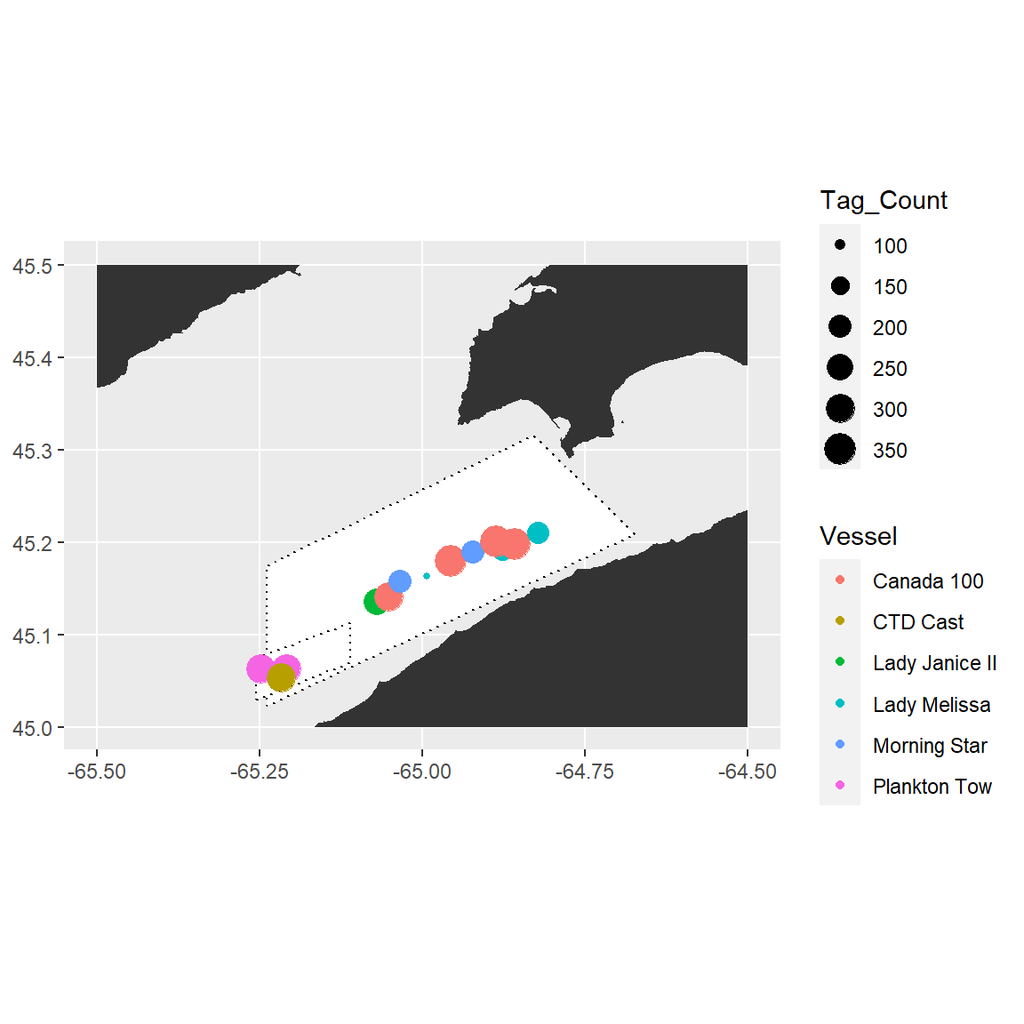

| Vessel | Tags |
| --- | --- |
| Canada 100 | 1354 |
| Lady Janice II | 250 |
| Lady Melissa | 472 |
| Morning Star | 400 |

### Plankton Data

#### Tow Summary Table

|  | Tow 1 | Tow 2 |
| --- | --- | --- |
| **Base Details** |  |  |
| Vessel | Lady Melissa | Lady Melissa |
| Set Number | SB2023-13 | SB2023-14 |
| Ground | SB | SB |
| Date | 27/08/2023 | 27/08/2023 |
| Wind Direction (km/h) | N | N |
| Swell (m) | 0 | 0 |
| Air Temp (c) | 19 | 19 |
| **Tow Details** |  |  |
| Tow Start | 18:56:00 | 19:18:00 |
| Tow End | 19:06:00 | 19:28:00 |
| Start Lat | 45.063 | 45.063 |
| End Lat | 45.07250 | 45.05933 |
| Start Lon | -65.24900 | -65.20883 |
| End Lon | -65.22550 | -65.22717 |
| Avg Tow Depth (m) | 3.048339 | 1.594508 |
| Speed | 6.8 | 5.3 |
| Heading | 60 | 246 |
| Tide Direction | with | against |
| **Other Data Collection** |  |  |
| Flow Start | 829707 | 885393 |
| Flow End | 885393 | 965658 |
| No. Revolutions | 55686 | 80265 |
| Distance (m) | 1496.450 | 2156.961 |
| Volume | 4701.097 | 6776.094 |
| Secchi Disappear (m) | 9 | 9 |
| Secchi Reappear (m) | 8 | 8 |

#### Tow Depth Profiles

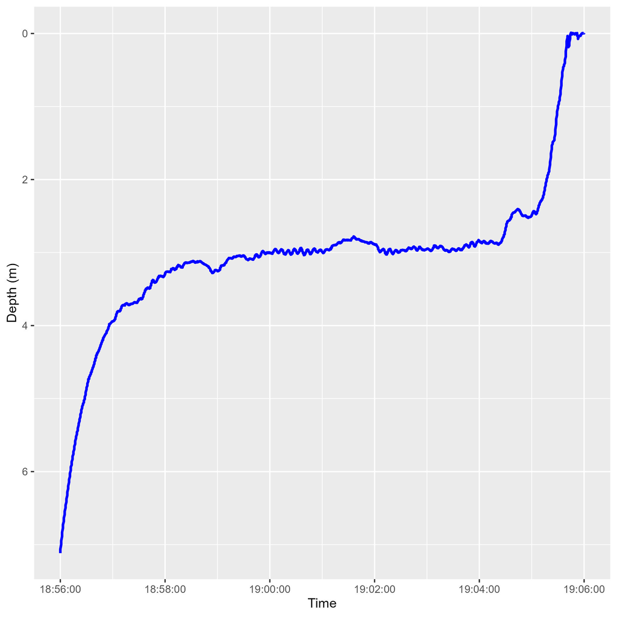

Plankton tow depth profile #1

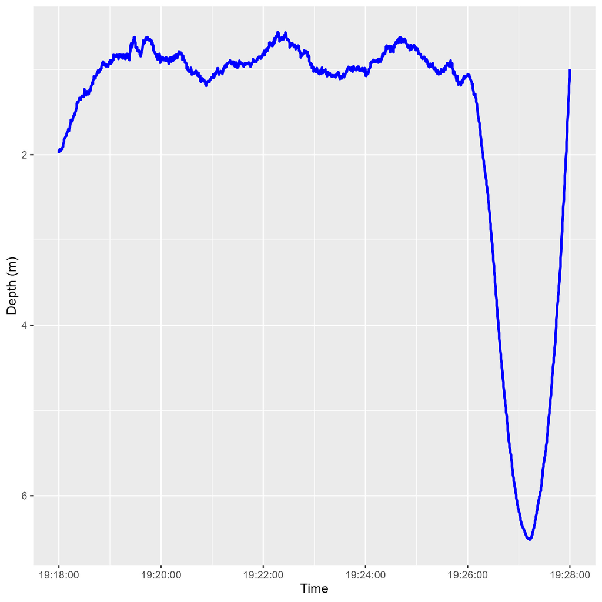

Plankton tow depth profile #2

The first tow is SB2023-13, which was with the tide and had an average depth of 3.048339m. The second tow is SB2023-14, which was against the tide and had an average depth of 1.5945077m.

#### Captured plankton

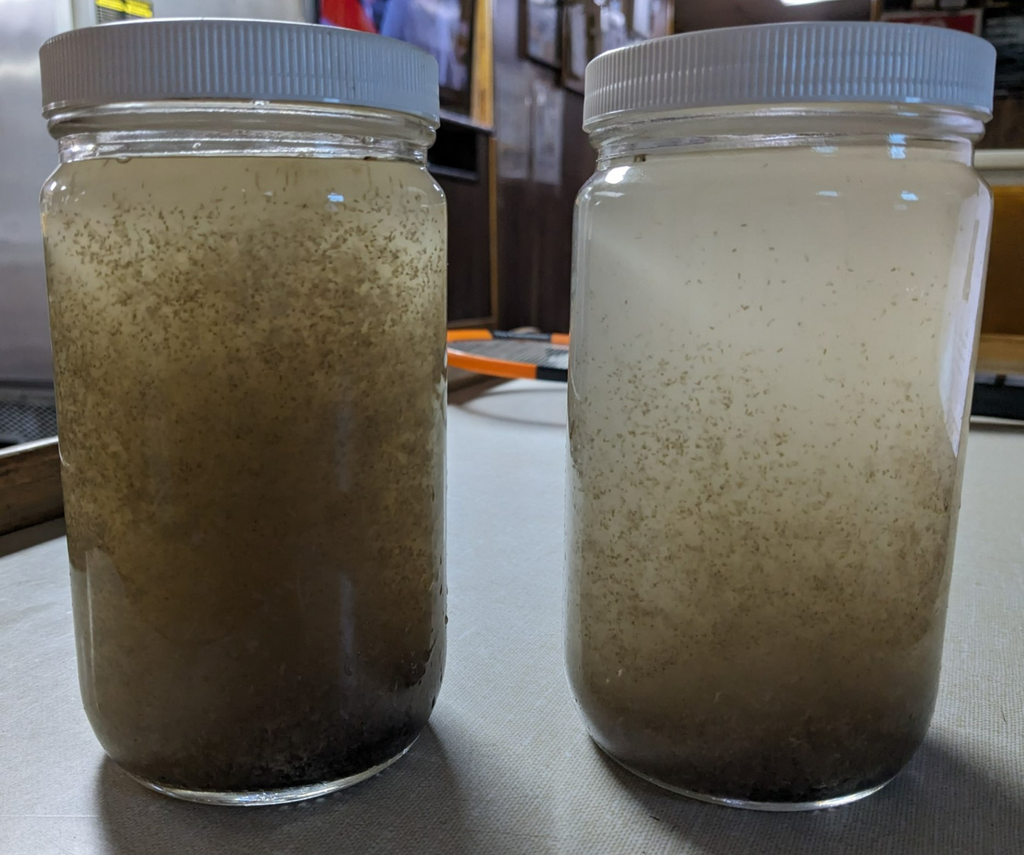

Captured plankton from the surface tows

### CTD Data

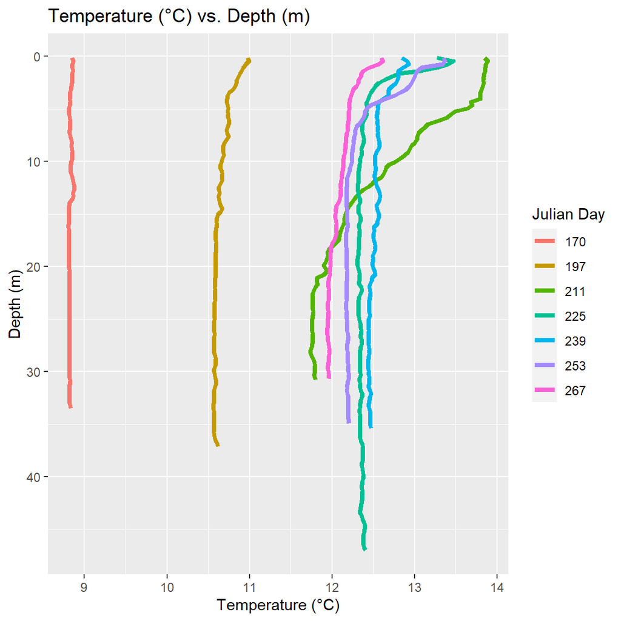

#### Sea surface temperatures

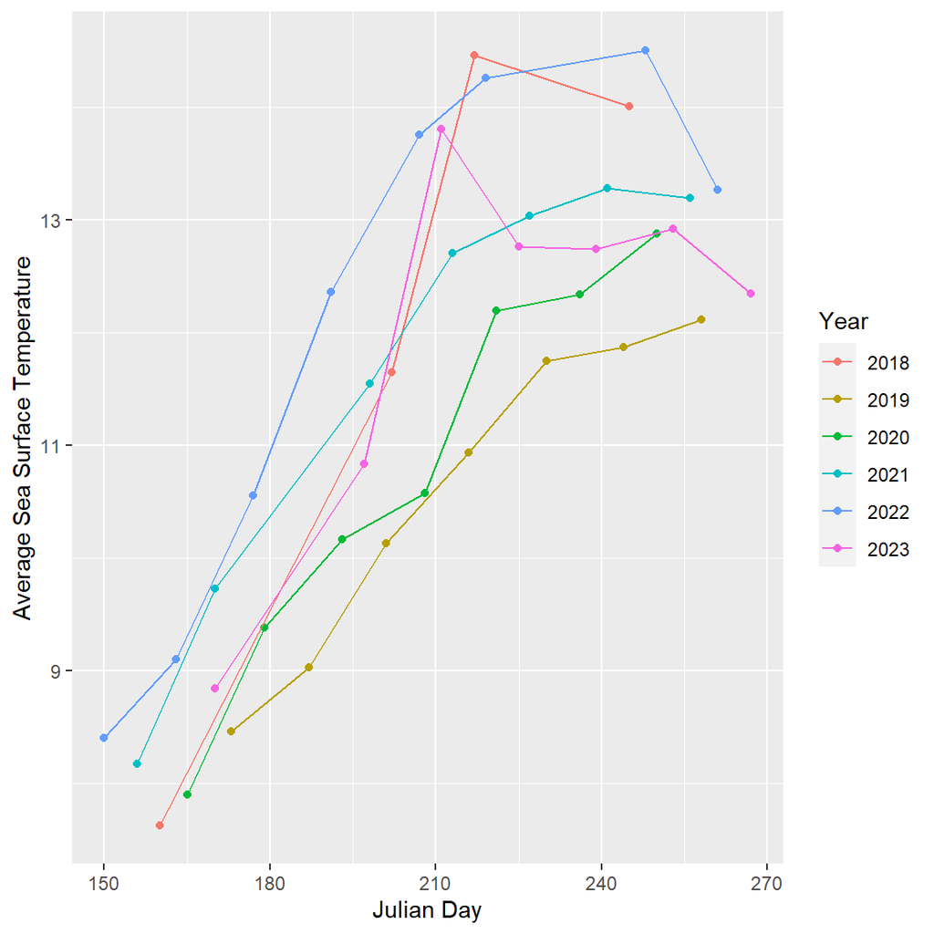

Annual average sea surface temperatures (SST) for Scots Bay.

## Vessel Performance

### Speed

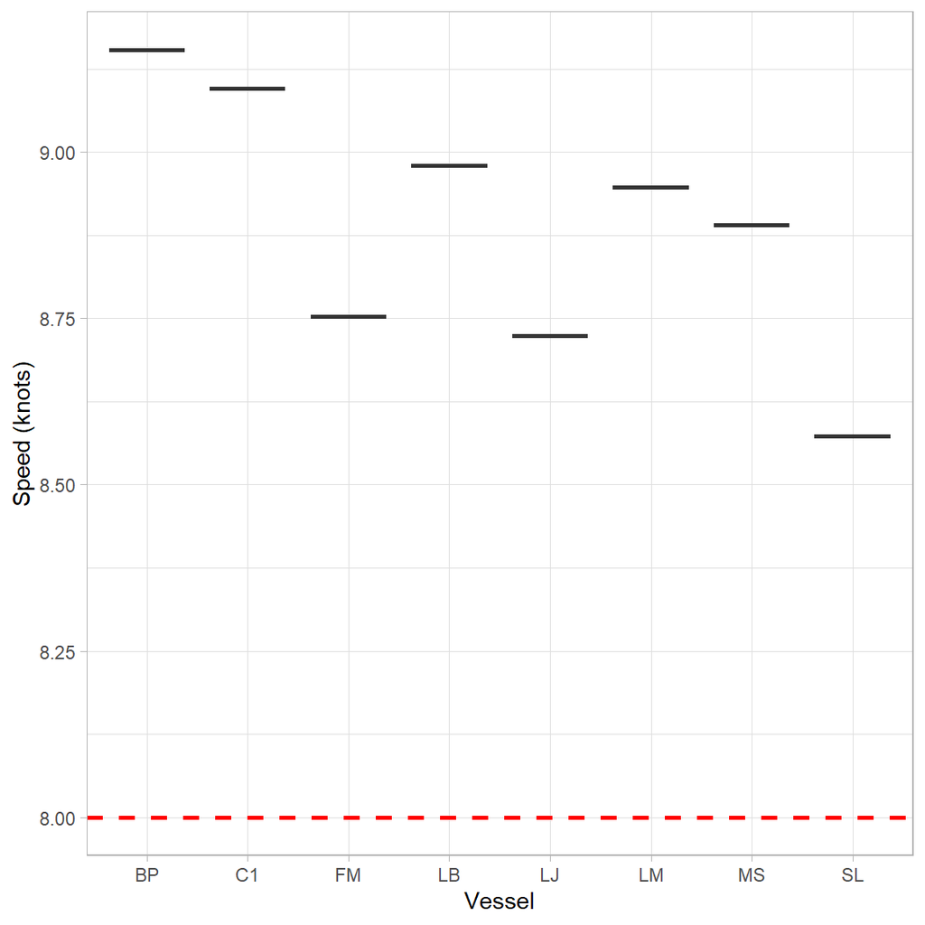

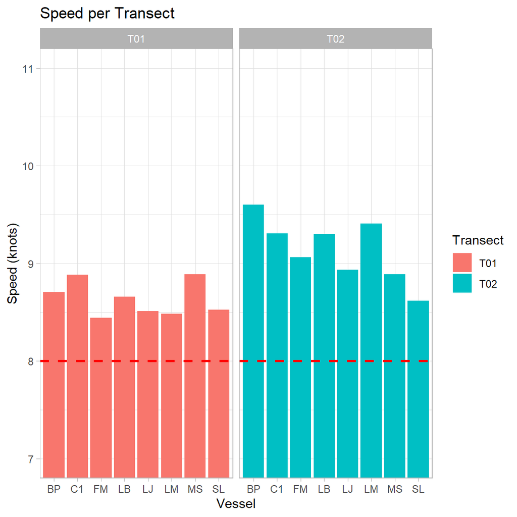

Average vessel speed was 8.89. This is above the 8 knot requirement; vessels are urged to slow down to prevent backscatter noise from interfering with the acoustic data.

### Distance

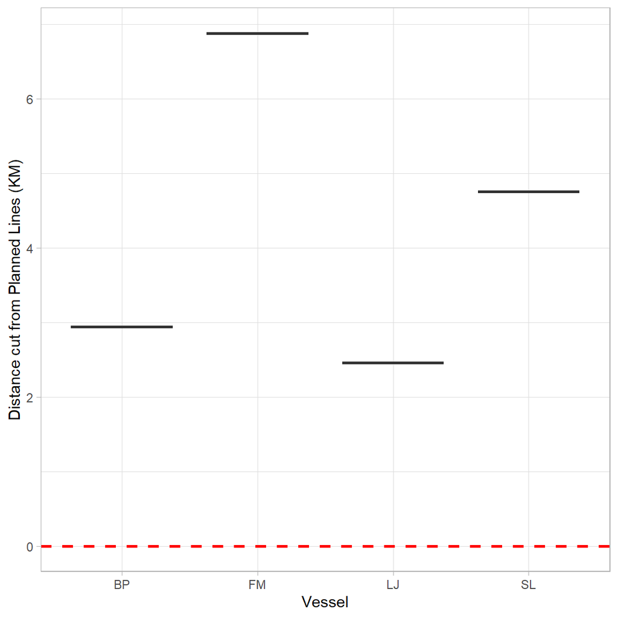

More than 2km of distance was cut from the planned lines; vessels are reminded to complete their assigned lines straight and without deviating or cutting corners short.